# February 6

# Packages

```r
library(car) # for Levene's test
library(tidyverse)
library(broom)
library(smmr) # to compare with ANOVA results
```

Intro: see slide 205

# A review example

See slides 207-208.

## The data

```r
my_url="http://www.utsc.utoronto.ca/~butler/d29/hairpain.txt"
hairpain=read_delim(my_url, " ")
hairpain
```

| hair | pain |
| --- | --- |
| lightblond | 62 |
| lightblond | 60 |
| lightblond | 71 |
| lightblond | 55 |
| lightblond | 48 |
| darkblond | 63 |
| darkblond | 57 |
| darkblond | 52 |
| darkblond | 41 |
| darkblond | 43 |

[output cut: 9 more lines]

Summary of means and SDs

```r
hairpain %>% group_by(hair) %>%
summarize( n=n(),xbar=mean(pain),s=sd(pain))
```

| hair | n | xbar | s |
| --- | --- | --- | --- |
| darkblond | 5 | 51.2 | 9.284396 |
| darkbrown | 5 | 37.4 | 8.324662 |
| lightblond | 5 | 59.2 | 8.526429 |
| lightbrown | 4 | 42.5 | 5.446712 |

Boxplot

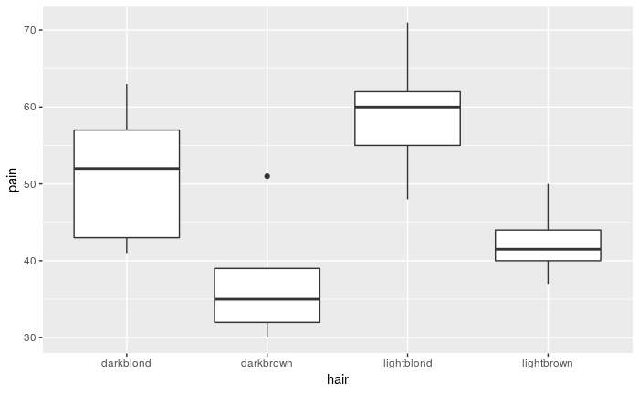

```r
ggplot(hairpain,aes(x=hair,y=pain))+geom_boxplot()
```

We have some potential problems with outliers and unequal spreads.

But brown-haired people seem to have less pain tolerance on average.

Are those spreads really unequal?

```r
leveneTest(pain~hair,data=hairpain)
```

```
group coerced to factor.
```

```
Levene's Test for Homogeneity of Variance (center = median)
      Df F value Pr(>F)
group  3  0.3927   0.76
      15
```

absolutely not! (Potential problem with small groups and testing for variance.)

## Analysis

ANOVA:

```r
hairpain.1=aov(pain~hair,data=hairpain)
summary(hairpain.1)
```

```
            Df Sum Sq Mean Sq F value  Pr(>F)
hair         3   1361   453.6   6.791 0.00411 **
Residuals   15   1002    66.8
---
Signif. codes:  0 ‘***’ 0.001 ‘**’ 0.01 ‘*’ 0.05 ‘.’ 0.1 ‘ ’ 1
```

There are differences in pain tolerance among the hair types. To find out which:

```r
TukeyHSD(hairpain.1)
```

```
  Tukey multiple comparisons of means
    95% family-wise confidence level

Fit: aov(formula = pain ~ hair, data = hairpain)

$hair
                       diff        lwr        upr     p adj
darkbrown-darkblond   -13.8 -28.696741  1.0967407 0.0740679
lightblond-darkblond    8.0  -6.896741 22.8967407 0.4355768
lightbrown-darkblond   -8.7 -24.500380  7.1003795 0.4147283
lightblond-darkbrown   21.8   6.903259 36.6967407 0.0037079
lightbrown-darkbrown    5.1 -10.700380 20.9003795 0.7893211
lightbrown-lightblond -16.7 -32.500380 -0.8996205 0.0366467
```

Light blond has significantly greater pain tolerance than light brown or dark brown.

Slide 216.

## Mood’s median test

Does `smmr` give same results, based on Mood’s median test?

```r
median_test(hairpain, pain, hair)
```

```
$table
            above
group        above below
  darkblond      3     2
  darkbrown      1     4
  lightblond     4     0
  lightbrown     1     3

$test
```

| what | value |
| --- | --- |
| statistic | 7.00000000 |
| df | 3.00000000 |
| P-value | 0.07189777 |

```
NA
```

Hmm, not quite significant at $\alpha=0.05$.

```r
pairwise_median_test(hairpain, pain, hair)
```

| g1 | g2 | p_value | adj_p_value |
| --- | --- | --- | --- |
| darkblond | darkbrown | 0.05777957 | 0.3466774 |
| darkblond | lightblond | 0.52708926 | 3.1625355 |
| darkblond | lightbrown | 0.15729921 | 0.9437952 |
| darkbrown | lightblond | 0.05777957 | 0.3466774 |
| darkbrown | lightbrown | 0.15729921 | 0.9437952 |
| lightblond | lightbrown | 0.02845974 | 0.1707584 |

No significant differences here at all.

## Issues

- different conclusions cause concern.
- maybe ANOVA not to be trusted because of unequal spreads/outliers (despite Levene’s test)
- maybe Mood lacks power because of small sample sizes.

# Data: rats and vitamin B

Slide 222 for background.

```r
my_url="http://www.utsc.utoronto.ca/~butler/d29/vitaminb.txt"
vitaminb=read_delim(my_url," ")
vitaminb
```

| ratsize | diet | kidneyweight |
| --- | --- | --- |
| lean | regular | 1.62 |
| lean | regular | 1.80 |
| lean | regular | 1.71 |
| lean | regular | 1.81 |
| lean | regular | 1.47 |
| lean | regular | 1.37 |
| lean | regular | 1.71 |
| lean | vitaminb | 1.51 |
| lean | vitaminb | 1.65 |
| lean | vitaminb | 1.45 |

[output cut: 18 more lines]

Kidney weight (response) depends on 2 factors rat size and diet.

## Grouped boxplot

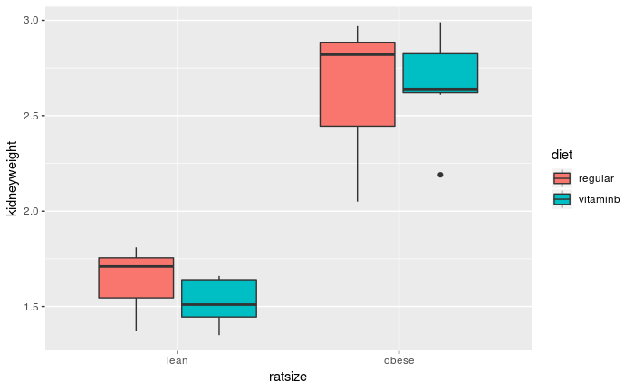

```r
ggplot(vitaminb,aes(x=ratsize, y=kidneyweight, fill=diet))+geom_boxplot()
```

Size: Lean rats have much smaller kidney weight than obese ones. Diet: difference is very small, maybe not significant.

## Group means

```r
summary = vitaminb %>% group_by(ratsize,diet) %>%
  summarize(mean=mean(kidneyweight))
summary
```

| ratsize | diet | mean |
| --- | --- | --- |
| lean | regular | 1.641429 |
| lean | vitaminb | 1.527143 |
| obese | regular | 2.642857 |
| obese | vitaminb | 2.672857 |

Almost same story as boxplot. Diet effect small (or non-existent).

## Interaction plot

With two factors, effect of one (eg. diet) on response may be different according to other factor (size), eg. one diet may be better for lean rats, and the other for obese rats.

To understand this, plot mean of response against one explanatory, with points joined by lines according to other. Need both `colour` and `group`:

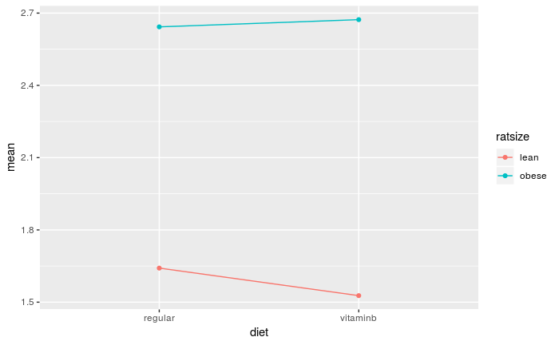

```r
ggplot(summary,aes(x=diet, y=mean, colour=ratsize, group=ratsize))+
  geom_point()+geom_line()
```

The two lines are more or less parallel, indicating no interaction.

I could also draw it like this:

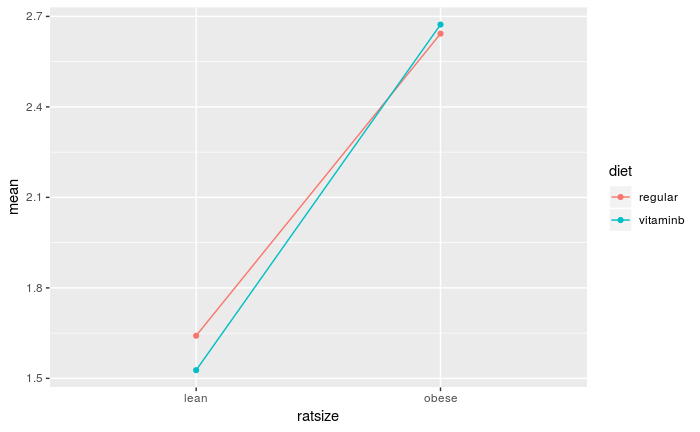

```r
ggplot(summary,aes(x=ratsize, y=mean, colour=diet, group=diet))+
  geom_point()+geom_line()
```

Two lines almost the same (almost no diet effect).

## ANOVA

Include *interaction*, to allow for possibility that effect of diet is different for lean and obese rats.

```r
vitaminb.1=aov(kidneyweight~ratsize*diet, data=vitaminb)
summary(vitaminb.1)
```

```
             Df Sum Sq Mean Sq F value   Pr(>F)
ratsize       1  8.068   8.068 141.179 1.53e-11 ***
diet          1  0.012   0.012   0.218    0.645
ratsize:diet  1  0.036   0.036   0.638    0.432
Residuals    24  1.372   0.057
---
Signif. codes:  0 ‘***’ 0.001 ‘**’ 0.01 ‘*’ 0.05 ‘.’ 0.1 ‘ ’ 1
```

Interaction is *not* significant. Effect of diet is same for both sizes of rat.

STOP HERE. Remove interaction before concluding anything else.

```r
vitaminb.2=update(vitaminb.1,.~.-ratsize:diet)
summary(vitaminb.2)
```

```
            Df Sum Sq Mean Sq F value   Pr(>F)
ratsize      1  8.068   8.068 143.256 7.59e-12 ***
diet         1  0.012   0.012   0.221    0.643
Residuals   25  1.408   0.056
---
Signif. codes:  0 ‘***’ 0.001 ‘**’ 0.01 ‘*’ 0.05 ‘.’ 0.1 ‘ ’ 1
```

Now interpret the main effects: size makes a difference but diet does not. If you like, remove diet as well:

```r
vitaminb.3=update(vitaminb.2,.~.-diet)
summary(vitaminb.3)
```

```
            Df Sum Sq Mean Sq F value   Pr(>F)
ratsize      1  8.068   8.068   147.7 3.17e-12 ***
Residuals   26  1.420   0.055
---
Signif. codes:  0 ‘***’ 0.001 ‘**’ 0.01 ‘*’ 0.05 ‘.’ 0.1 ‘ ’ 1
```

There were only two sizes, so one of them must have bigger kidneys than the other:

```r
summary
```

| ratsize | diet | mean |
| --- | --- | --- |
| lean | regular | 1.641429 |
| lean | vitaminb | 1.527143 |
| obese | regular | 2.642857 |
| obese | vitaminb | 2.672857 |

The obese rats have bigger kidneys, but the diet has no effect.

# Auto noise data

Slide 230 for background.

```r
my_url="http://www.utsc.utoronto.ca/~butler/d29/autonoise.txt"
autonoise=read_table(my_url)
autonoise
```

| noise | size | type | side |
| --- | --- | --- | --- |
| 840 | M | Std | R |
| 770 | L | Octel | L |
| 820 | M | Octel | R |
| 775 | L | Octel | R |
| 825 | M | Octel | L |
| 840 | M | Std | R |
| 845 | M | Std | L |
| 825 | M | Octel | L |
| 815 | M | Octel | L |
| 845 | M | Std | R |

[output cut: 26 more lines]

Two explanatory factors `size` and `type` (ignore `side`). What is effect of each and do they interact?

## Grouped boxplot

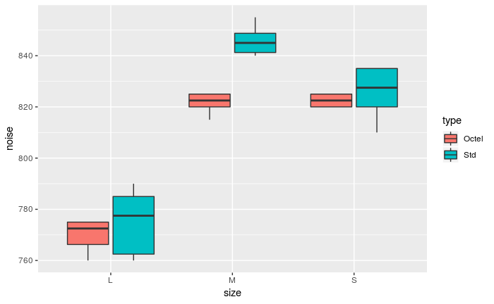

```r
ggplot(autonoise, aes(x=size,y=noise,fill=type))+
   geom_boxplot()
```

Octel filter seems to have equal or less noise on average, with difference for medium engines.

Compare:

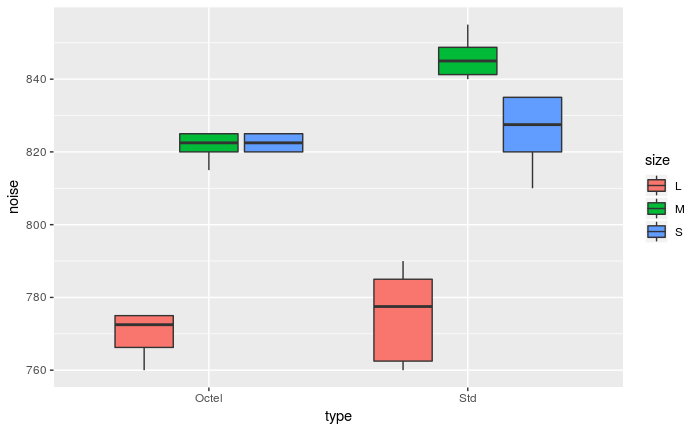

```r
ggplot(autonoise, aes(x=type,y=noise,fill=size))+
   geom_boxplot()
```

I like having more smaller groups (use as `x` the categorical variable with more categories).

## Interaction plot

Two ways.

1. compute means and pipe into plot:

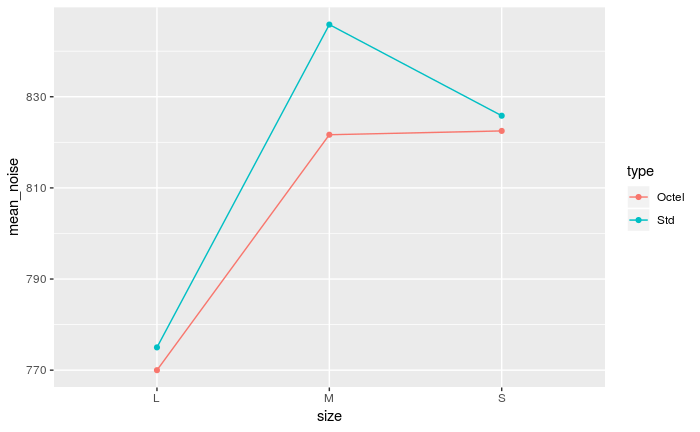

```r
autonoise %>% group_by(type, size) %>%
  summarize(mean_noise=mean(noise)) %>%
  ggplot(aes(x=size, y=mean_noise, colour=type, group=type))+
    geom_point()+geom_line()
```

Not parallel: expect interaction.

2. have ggplot compute means for us:

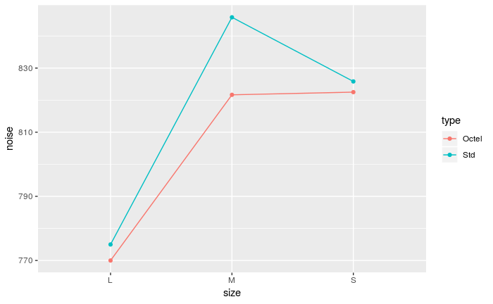

```r
ggplot(autonoise,aes(x=size,y=noise,
  colour=type,group=type))+
  stat_summary(fun.y=mean,geom="point")+
  stat_summary(fun.y=mean,geom="line")
```

Same plot, but uses *original* data and *computes* means by group.

Variation: plot original data as points instead:

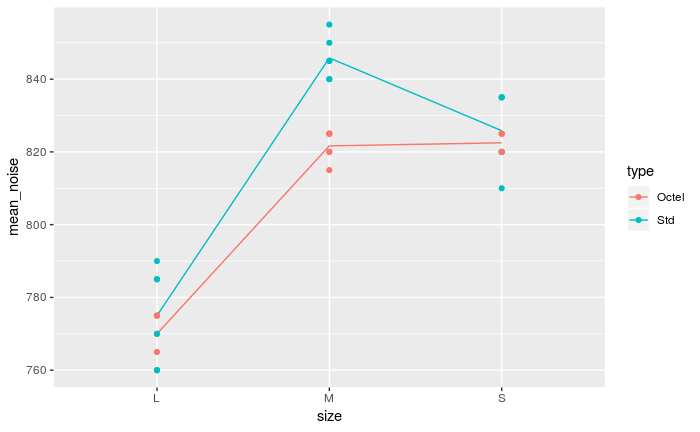

```r
autonoise %>% group_by(type, size) %>%
  summarize(mean_noise=mean(noise)) %>%
  ggplot(aes(x=size, y=mean_noise, colour=type, group=type))+
    geom_line()+
    geom_point(data=autonoise, aes(y=noise))
```

## ANOVA

Include interaction term:

```r
autonoise.1=aov(noise~size*type,data=autonoise)
summary(autonoise.1)
```

```
            Df Sum Sq Mean Sq F value   Pr(>F)
size         2  26051   13026 199.119  < 2e-16 ***
type         1   1056    1056  16.146 0.000363 ***
size:type    2    804     402   6.146 0.005792 **
Residuals   30   1962      65
---
Signif. codes:  0 ‘***’ 0.001 ‘**’ 0.01 ‘*’ 0.05 ‘.’ 0.1 ‘ ’ 1
```

Interaction is significant. That is our finding: effect of filter type is different for different engine sizes.

How? Tukey?

```r
TukeyHSD(autonoise.1)
```

```
  Tukey multiple comparisons of means
    95% family-wise confidence level

Fit: aov(formula = noise ~ size * type, data = autonoise)

$size
         diff       lwr       upr     p adj
M-L 61.250000  53.10983 69.390167 0.0000000
S-L 51.666667  43.52650 59.806833 0.0000000
S-M -9.583333 -17.72350 -1.443167 0.0183324

$type
              diff      lwr      upr     p adj
Std-Octel 10.83333 5.327328 16.33934 0.0003631

$`size:type`
                       diff        lwr        upr     p adj
M:Octel-L:Octel  51.6666667  37.463511  65.869823 0.0000000
S:Octel-L:Octel  52.5000000  38.296844  66.703156 0.0000000
L:Std-L:Octel     5.0000000  -9.203156  19.203156 0.8890358
M:Std-L:Octel    75.8333333  61.630177  90.036489 0.0000000
S:Std-L:Octel    55.8333333  41.630177  70.036489 0.0000000
S:Octel-M:Octel   0.8333333 -13.369823  15.036489 0.9999720
L:Std-M:Octel   -46.6666667 -60.869823 -32.463511 0.0000000
M:Std-M:Octel    24.1666667   9.963511  38.369823 0.0001909
S:Std-M:Octel     4.1666667 -10.036489  18.369823 0.9454142
L:Std-S:Octel   -47.5000000 -61.703156 -33.296844 0.0000000
M:Std-S:Octel    23.3333333   9.130177  37.536489 0.0003130
S:Std-S:Octel     3.3333333 -10.869823  17.536489 0.9787622
M:Std-L:Std      70.8333333  56.630177  85.036489 0.0000000
S:Std-L:Std      50.8333333  36.630177  65.036489 0.0000000
S:Std-M:Std     -20.0000000 -34.203156  -5.796844 0.0022033
```

ouch!

## Simple effects

Comparing eg. large engine, standard filter vs medium engine, Octel filter not what we really care about.

Interested in comparing the two filters on the *same* size engine.

That is, look only at engines of a certain size, and see whether there is an effect of filter type for those engines.

Called *simple effects* of filter type for each engine size.

Expect: simple effect of filter type for Medium engines to be significant, for other engines not to be.

Procedure: extract only data of required engine size, do *1-way ANOVA* of noise on filter type, interpret.

Small engines first:

```r
autonoise %>% filter(size=="S") %>%
  aov(noise~type, data=.) -> autonoise.2a
summary(autonoise.2a)
```

```
            Df Sum Sq Mean Sq F value Pr(>F)
type         1   33.3   33.33   0.548  0.476
Residuals   10  608.3   60.83
```

No significant difference. Medium engines?

```r
autonoise %>% filter(size=="M") %>%
  aov(noise~type, data=.) -> autonoise.2b
summary(autonoise.2b)
```

```
            Df Sum Sq Mean Sq F value   Pr(>F)
type         1 1752.1  1752.1   68.93 8.49e-06 ***
Residuals   10  254.2    25.4
---
Signif. codes:  0 ‘***’ 0.001 ‘**’ 0.01 ‘*’ 0.05 ‘.’ 0.1 ‘ ’ 1
```

Strongly significant. Which way?

```r
TukeyHSD(autonoise.2b )
```

```
  Tukey multiple comparisons of means
    95% family-wise confidence level

Fit: aov(formula = noise ~ type, data = .)

$type
              diff     lwr      upr   p adj
Std-Octel 24.16667 17.6812 30.65213 8.5e-06
```

Noise is higher for Standard filters than Octel ones.

Large engines?

```r
autonoise %>% filter(size=="L") %>%
  aov(noise~type, data=.) -> autonoise.2c
summary(autonoise.2c)
```

```
            Df Sum Sq Mean Sq F value Pr(>F)
type         1     75      75   0.682  0.428
Residuals   10   1100     110
```

No significant difference again.

These three are exactly what we expected: Octel filters never have more noise than Standard ones, and sometimes have less. This is what the President of Texaco wanted to show.

## All at once

```r
autonoise %>% group_by(size) %>%  nest()
```

| size | data |
| --- | --- |
| M |  |
| L |  |
| S |  |

`data` contains all the rest of the data apart from size.

“For each thing in `data`, run `aov` predicting noise from type”:

```r
autonoise %>% group_by(size) %>%  nest() %>%
  mutate(aovs=map(data, ~aov(noise~type, data=.)))
```

| size | data | aovs |
| --- | --- | --- |
| M |  |  |
| L |  |  |
| S |  |  |

How to get at the P-value?

```r
glance(autonoise.2a)$p.value
```

```
[1] 0.4761786
```

so

```r
autonoise %>% group_by(size) %>%  nest() %>%
  mutate(aovs=map(data, ~aov(noise~type, data=.))) %>%
  mutate(pval=map_dbl(aovs, ~glance(.)$p.value))
```

| size | data | aovs | pval |
| --- | --- | --- | --- |
| M |  |  | 8.492967e-06 |
| L |  |  | 4.282210e-01 |
| S |  |  | 4.761786e-01 |

or

```r
autonoise %>% group_by(size) %>%  nest() %>%
  mutate(aovs=map(data, ~aov(noise~type, data=.))) %>%
  mutate(glancing=map(aovs, ~as_tibble(glance(.)))) %>%
  unnest(glancing)
```

| size | data | aovs | r.squared | adj.r.squared | sigma | statistic | p.value | df | logLik | AIC | BIC | deviance | df.residual |
| --- | --- | --- | --- | --- | --- | --- | --- | --- | --- | --- | --- | --- | --- |
| M |  |  | 0.87331256 | 0.86064382 | 5.041494 | 68.9344262 | 8.492967e-06 | 2 | -35.34576 | 76.69153 | 78.14625 | 254.1667 | 10 |
| L |  |  | 0.06382979 | -0.02978723 | 10.488088 | 0.6818182 | 4.282210e-01 | 2 | -44.13622 | 94.27243 | 95.72715 | 1100.0000 | 10 |
| S |  |  | 0.05194805 | -0.04285714 | 7.799573 | 0.5479452 | 4.761786e-01 | 2 | -40.58216 | 87.16432 | 88.61904 | 608.3333 | 10 |

# Contrasts in ANOVA

Slide 255.

## Data: chainsaw kickback

```r
my_url="http://www.utsc.utoronto.ca/~butler/d29/chainsaw.txt"
chain.wide=read_table(my_url)
chain.wide
```

| A | B | C | D |
| --- | --- | --- | --- |
| 42 | 28 | 57 | 29 |
| 17 | 50 | 45 | 29 |
| 24 | 44 | 48 | 22 |
| 39 | 32 | 41 | 34 |
| 43 | 61 | 54 | 30 |

Tidy:

```r
chain=gather(chain.wide, chainsaw, kickback, everything(), factor_key=T)
chain
```

| chainsaw | kickback |
| --- | --- |
| A | 42 |
| A | 17 |
| A | 24 |
| A | 39 |
| A | 43 |
| B | 28 |
| B | 50 |
| B | 44 |
| B | 32 |
| B | 61 |

[output cut: 10 more lines]

Note that `chainsaw` is a `factor` (which we will need).

What are the chainsaws, in order?

```r
chain %>% count(chainsaw)
```

| chainsaw | n |
| --- | --- |
| A | 5 |
| B | 5 |
| C | 5 |
| D | 5 |

## Contrasts

Want to compare (only):

1. home chainsaws A and D with industrial ones B and C
2. two home chainsaws A and D with each other
3. two industrial chainsaws B and C with each other

Other comparisons not of interest.

See slides 258-259.

Create vectors with coefficients that represent what you want to compare with what.

Eg. contrast 2 looks like this:

```r
c2=c(1,0,0,-1)
```

and contrast 3:

```r
c3=c(0,1,-1,0)
```

Things that don’t appear in a contrast should be zero, and things compared with each other should be of opposite signs and the same size.

Contrast 1 is “average of A and D vs. average of B and C”, thus:

```r
c1=c(1/2, -1/2, -1/2, 1/2)
```

So far we have:

```r
c1
```

```
[1]  0.5 -0.5 -0.5  0.5
```

```r
c2
```

```
[1]  1  0  0 -1
```

```r
c3
```

```
[1]  0  1 -1  0
```

If you elementwise-multiply contrasts 2 and 3 together and add up, you get zero:

```r
sum(c2*c3)
```

```
[1] 0
```

These two contrasts are called *orthogonal*. We only learn how to deal with orthogonal contrasts. In fact `c1` is orthogonal to the others as well:

```r
sum(c1*c2)
```

```
[1] 0
```

```r
sum(c1*c3)
```

```
[1] 0
```

## Setting up contrasts

- arrange into matrix with `cbind`
- tell `lm` that you want to use these contrasts

```r
m=cbind(c1, c2, c3)
m
```

```
       c1 c2 c3
[1,]  0.5  1  0
[2,] -0.5  0  1
[3,] -0.5  0 -1
[4,]  0.5 -1  0
```

```r
contrasts(chain$chainsaw)=m
```

## Fit as `lm`

Then fit ANOVA *as `lm`* and look at `summary`:

```r
chain.1=lm(kickback~chainsaw,data=chain)
summary(chain.1)
```

```
Call:
lm(formula = kickback ~ chainsaw, data = chain)

Residuals:
   Min     1Q Median     3Q    Max
-16.00  -7.10   0.60   6.25  18.00

Coefficients:
            Estimate Std. Error t value Pr(>|t|)
(Intercept)   38.450      2.179  17.649 6.52e-12 ***
chainsawc1   -15.100      4.357  -3.466  0.00319 **
chainsawc2     2.100      3.081   0.682  0.50524
chainsawc3    -3.000      3.081  -0.974  0.34469
---
Signif. codes:  0 ‘***’ 0.001 ‘**’ 0.01 ‘*’ 0.05 ‘.’ 0.1 ‘ ’ 1

Residual standard error: 9.743 on 16 degrees of freedom
Multiple R-squared:  0.4562,    Adjusted R-squared:  0.3542
F-statistic: 4.474 on 3 and 16 DF,  p-value: 0.01833
```

## Conclusions

The lines `chainsawc1` through `chainsawc3` are the tests for the three contrasts 1 through 3:

1. The home models and industrial models differ significantly in kickback.
2. The two home models do not differ significantly in kickback (from each other)
3. The two industrial models do not differ significantly in kickback (from each other).

To understand 1, we can compute means:

```r
chain %>% group_by(chainsaw) %>%
  summarize(m=mean(kickback))
```

| chainsaw | m |
| --- | --- |
| A | 33.0 |
| B | 43.0 |
| C | 49.0 |
| D | 28.8 |

The two industrial models B and C have *greater* kickback than the home models A and D, which makes sense because in an industrial setting, users would get training to handle the chainsaw safely.

This is all we needed to test, so we are done.